# Normal Distribution

Gustavo Fernandez

4/3/2020

### The likelihood function

The likelihood function for a normal distribution represents the product of the density function, given values of $\mu$,$\sigma$ given the values of x.
${L}$=($\mu$,$\sigma$|$x_i$)= $\Pi_{i=1}^{n}$$\frac{1}{\sqrt(2\pi\sigma^2)}$exp-($\frac{(x_i-\mu)^2}{2\sigma^2}$)

### Log-likelihood

Log-likelihood function is a logarithmic transformation of the likelihood function, often denoted by a lowercase l. Since concavity plays a key role in the maximization, and as the most common probability distributions—in particular the exponential family—are only logarithmically concave, it is usually more convenient to work with the log-likelihood function. Also, the log-likelihood is particularly convenient for maximum likelihood estimation. Because logarithms are strictly increasing functions, maximizing the likelihood is equivalent to maximizing the log-likelihood.

The log likelihood of a normally distributed variable:
$\sum_{i=1}^{n}$$-\frac{n}{2}\ln(2\pi) -nln(\sigma)-\frac{(x_i-\mu)^2}{2\sigma^2}$

### Data

Consider taking a random sample of 50 with replacement.

```r
population=rnorm(1200,mean=37,sd=20)
x=sample(population, 50, replace = TRUE) #sample
```

Assume, the standard deviation is fixed at $\sigma=20$. Then, we wish to find the Maximum likelihood for the estimate $\mu$ given the sample.

Therefore, the log likelihood of a normally distributed variable with fixed $\sigma=20$:  
$\sum_{i=1}^{n}$-$\frac{n}{2}\ln(2\pi) -nln(2)-\frac{(x_i-\mu)^2}{2*400}$

Below is the log likelihood function in R:

```r
lognormalF <- function(mu) {
# Log of likelihood of a normal distribution

  sum ( -0.5* log(2*pi) -log(2) - 0.5*(x - mu)^2/(400)) #sigma is fixed at 20

        }
```

### Plot the Log Likelihood Function

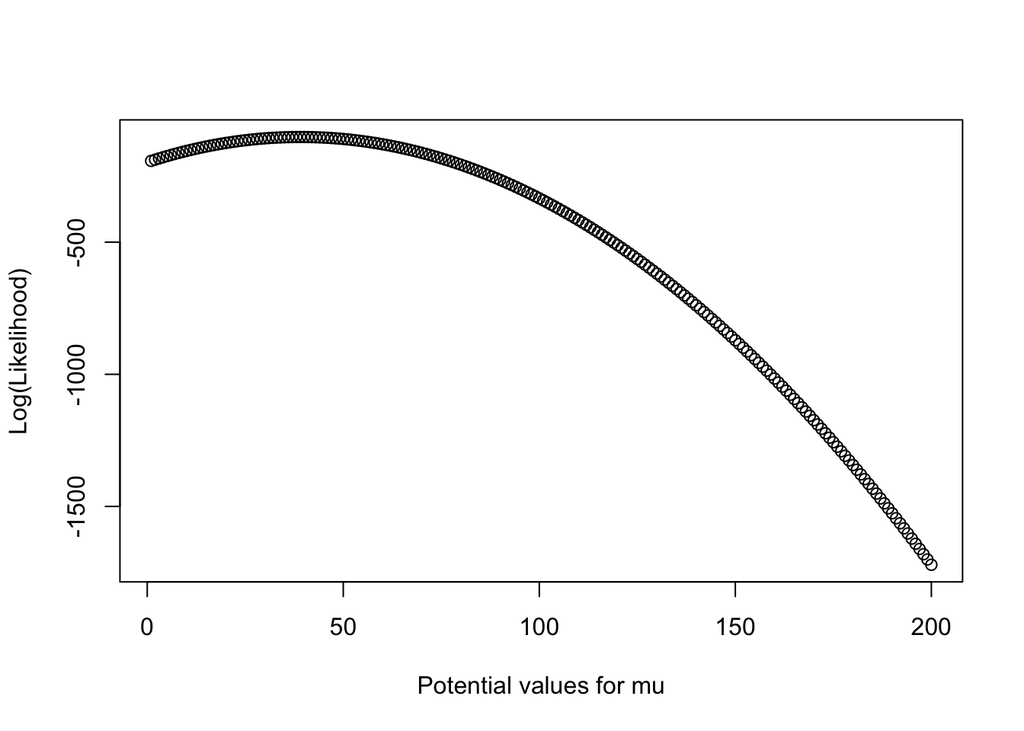

```r
potentialvaluesformu<-(1:200)
storage<-rep(NA,length(potentialvaluesformu))

for(i in potentialvaluesformu) {

  storage[i]<-lognormalF(i)

}

plot(potentialvaluesformu,storage,ylab="Log(Likelihood)",xlab="Potential values for mu")
```

To find the maximum likelihood estimate for $\mu$, we need to solve for where the derivative with respect to $\mu=0$, because the slop is 0 at the peak of the curve. now, we find that the derivative of the log-likelihood function with respect to $\mu$ is:  
$\frac{1}{\sigma^2}[\sum{x_i} - n\mu]$

So, we need now we find the root of:  
$\frac{1}{400}[\sum{x_i} - n\mu]=0$  
In R:

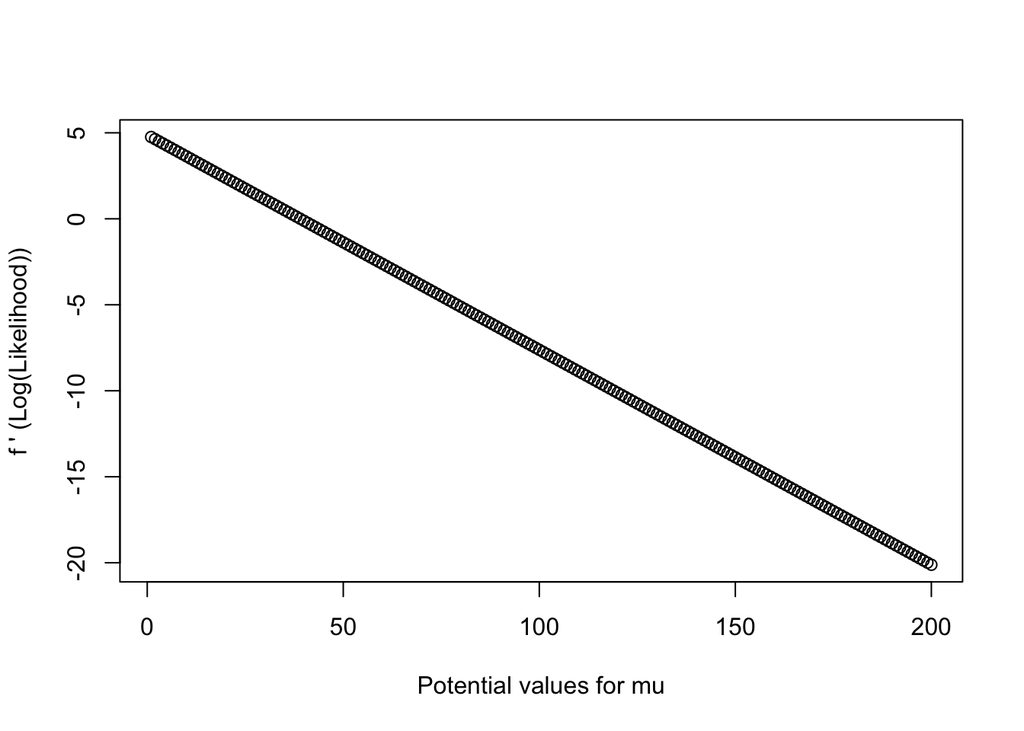

```r
dlognormalF <- function(mu) {
# derivate of log likelihood function with respect to Mu

 (1/400) * (sum(x) - length(x)*mu)

}

potentialvaluesformu<-(1:200)
storage2<-rep(NA,length(potentialvaluesformu))

for(i in potentialvaluesformu) {

  storage2[i]<-dlognormalF(i)

}

plot(potentialvaluesformu,storage2,ylab="f ' (Log(Likelihood))",xlab="Potential values for mu")
```

Therefore,

The maximum likelihood estimate for $\mu$ is:

```r
# find where the derivative function is zero

uniroot(dlognormalF,c(1,100))
```

```
## $root
## [1] 39.05647
##
## $f.root
## [1] -5.684342e-16
##
## $iter
## [1] 2
##
## $init.it
## [1] NA
##
## $estim.prec
## [1] 6.103516e-05
```

### Simulation Sample Size

```r
#10 interaction sample size 3 Maximum Likelihood estimator for mu
for (i in 1:10){
x<-sample(population,3,replace=TRUE)
root<-uniroot(dlognormalF, c(0,130))
print(root$root)
}
```

```
## [1] 27.7919
## [1] 33.10582
## [1] 25.55593
## [1] 35.04903
## [1] 32.35534
## [1] 32.54785
## [1] 25.01726
## [1] 50.63796
## [1] 42.6214
## [1] 41.54956
```

```r
#10 interaction sample size 5 Maximum Likelihood estimator for mu
for (i in 1:10){
x<-sample(population,5,replace=TRUE)
root<-uniroot(dlognormalF, c(0,130))
print(root$root)
}
```

```
## [1] 28.26654
## [1] 38.94159
## [1] 36.21739
## [1] 41.11802
## [1] 57.15191
## [1] 32.38566
## [1] 32.67121
## [1] 41.87511
## [1] 23.66838
## [1] 31.97981
```

```r
#10 interaction sample size 20 Maximum Likelihood estimator for mu
for (i in 1:10){
x<-sample(population,20,replace=TRUE)
root<-uniroot(dlognormalF, c(0,130))
print(root$root)
}
```

```
## [1] 31.56822
## [1] 36.04114
## [1] 42.40033
## [1] 43.20699
## [1] 31.32277
## [1] 36.08461
## [1] 40.25332
## [1] 35.92494
## [1] 37.77914
## [1] 33.59432
```

```r
#10 interaction sample size 50 Maximum Likelihood estimator for mu
for (i in 1:10){
x<-sample(population,50,replace=TRUE)
root<-uniroot(dlognormalF, c(0,130))
print(root$root)
}
```

```
## [1] 38.90316
## [1] 38.87964
## [1] 32.94976
## [1] 36.85692
## [1] 36.3182
## [1] 40.23039
## [1] 39.31819
## [1] 39.32558
## [1] 35.27348
## [1] 40.37064
```

```r
#10 interaction sample size 100 Maximum Likelihood estimator for mu
for (i in 1:10){
x<-sample(population,100,replace=TRUE)
root<-uniroot(dlognormalF, c(0,130))
print(root$root)
}
```

```
## [1] 36.71024
## [1] 31.49511
## [1] 37.12258
## [1] 36.18389
## [1] 38.70985
## [1] 37.20575
## [1] 37.32848
## [1] 34.05014
## [1] 36.76883
## [1] 34.45746
```

```r
#10 interaction sample size 500 Maximum Likelihood estimator for mu
for (i in 1:10){
x<-sample(population,500,replace=TRUE)
root<-uniroot(dlognormalF, c(0,130))
print(root$root)
}
```

```
## [1] 35.725
## [1] 35.62368
## [1] 35.17955
## [1] 36.70483
## [1] 36.20348
## [1] 35.69643
## [1] 36.29887
## [1] 38.30237
## [1] 35.40447
## [1] 37.83139
```

### Conclusions

In the analysis the convinience of using the log-likelihood for maximum likelihood estimation has been documented. Also, have been shown in the analysis that the maximum likelihood estimator for the population mean is approximately equal to the sample mean $\mu$ $\approx$ $\hat {x}$. This is particularly the case since the sample mean $\hat {x}$ is known to be an unbiased estimador for $\mu$.Futhermore, the maximum likelihood estimador get closer to the true value of $\mu$ as the sample size $n$ increases.